# heart_attack

analysis

2025-05-11

## Dataset Description

Ce dataset contient des données cliniques de patients utilisées pour déterminer la présence ou non d’un problème cardiaque.

Chaque ligne correspond à un patient, avec plusieurs caractéristiques mesurées lors d’un examen médical.

• L’âge des patients varie, et il est indiqué dans la colonne Age, en années.

• Le sexe des patients est codé dans la colonne Gender, où 0 représente un homme et 1 représente une femme.

• La fréquence cardiaque (Heart.rate) est mesurée en battements par minute.

• La pression artérielle est divisée en deux mesures : la pression systolique (Systolic.blood.pressure) et la pression diastolique (Diastolic.blood.pressure), exprimées en mmHg.

• La colonne Blood.sugar indique le taux de sucre dans le sang, mesuré en mg/dL.

• Le niveau de CK-MB (CK.MB) est un indicateur enzymatique de dommages au muscle cardiaque. Des niveaux élevés peuvent signaler une crise cardiaque.

• La Troponin est une protéine libérée lors d’un infarctus du myocarde ; elle est considérée comme un marqueur très spécifique de lésions cardiaques.

• Enfin, la colonne Result contient le diagnostic final : “positive” signifie que le patient présente des signes de problème cardiaque, tandis que “negative” signifie qu’aucune anomalie n’a été détectée

```r
data <- read.csv("Medicaldataset.csv", sep=",", dec=".", header=TRUE, stringsAsFactors=TRUE)
head(data)
```

```
##   Age Gender Heart.rate Systolic.blood.pressure Diastolic.blood.pressure
## 1  64      1         66                     160                       83
## 2  21      1         94                      98                       46
## 3  55      1         64                     160                       77
## 4  64      1         70                     120                       55
## 5  55      1         64                     112                       65
## 6  58      0         61                     112                       58
##   Blood.sugar CK.MB Troponin   Result
## 1         160  1.80    0.012 negative
## 2         296  6.75    1.060 positive
## 3         270  1.99    0.003 negative
## 4         270 13.87    0.122 positive
## 5         300  1.08    0.003 negative
## 6          87  1.83    0.004 negative
```

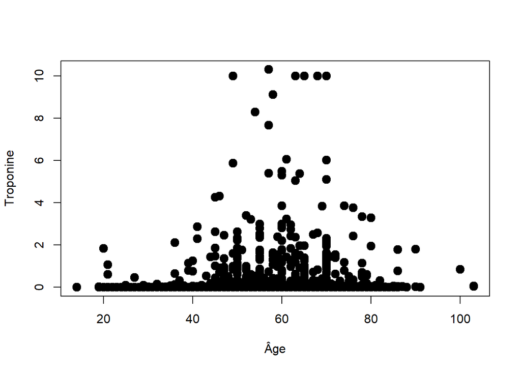

```r
## Ce graphique montre qu'il n'y a pas de relation claire entre l’âge et le taux de troponine. La majorité des valeurs sont proches de zéro, surtout entre 40 et 80 ans, avec quelques pics élevés.
plot(data$Age, data$Troponin, xlab = "Âge", ylab = "Troponine", pch = 19, cex = 1.5)
```

```r
names(data)
```

```
## [1] "Age"                      "Gender"
## [3] "Heart.rate"               "Systolic.blood.pressure"
## [5] "Diastolic.blood.pressure" "Blood.sugar"
## [7] "CK.MB"                    "Troponin"
## [9] "Result"
```

```r
nrow(data)
```

```
## [1] 1319
```

```r
ncol(data)
```

```
## [1] 9
```

```r
typeof(data)
```

```
## [1] "list"
```

```r
str(data)
```

```
## 'data.frame':    1319 obs. of  9 variables:
##  $ Age                     : int  64 21 55 64 55 58 32 63 44 67 ...
##  $ Gender                  : int  1 1 1 1 1 0 0 1 0 1 ...
##  $ Heart.rate              : int  66 94 64 70 64 61 40 60 60 61 ...
##  $ Systolic.blood.pressure : int  160 98 160 120 112 112 179 214 154 160 ...
##  $ Diastolic.blood.pressure: int  83 46 77 55 65 58 68 82 81 95 ...
##  $ Blood.sugar             : num  160 296 270 270 300 87 102 87 135 100 ...
##  $ CK.MB                   : num  1.8 6.75 1.99 13.87 1.08 ...
##  $ Troponin                : num  0.012 1.06 0.003 0.122 0.003 0.004 0.003 2.37 0.004 0.011 ...
##  $ Result                  : Factor w/ 2 levels "negative","positive": 1 2 1 2 1 1 1 2 1 1 ...
```

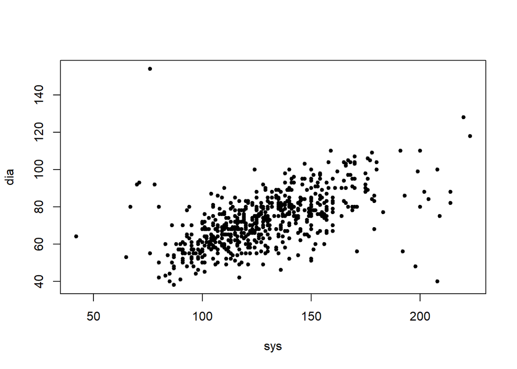

```r
##Ce graphique montre une corrélation positive entre la pression systolique (sys) et la pression diastolique (dia) : plus la pression systolique est élevée, plus la pression diastolique tend à l’être aussi.
plot(data$Systolic.blood.pressure, data$Diastolic.blood.pressure, xlab = "sys", ylab = "dia", cex = 1, pch = 20)
```

```r
dim(data)
```

```
## [1] 1319    9
```

```r
##La commande colSums(is.na(data)) montre qu’il n’y a aucune valeur manquante dans les colonnes du jeu de données. Toutes les variables sont complètes et prêtes pour l’analyse.
colSums(is.na(data))
```

```
##                      Age                   Gender               Heart.rate
##                        0                        0                        0
##  Systolic.blood.pressure Diastolic.blood.pressure              Blood.sugar
##                        0                        0                        0
##                    CK.MB                 Troponin                   Result
##                        0                        0                        0
```

```r
duplicated_rows <- duplicated(data)
duplicated_data <- data[duplicated_rows, ]
duplicated_data
```

```
## [1] Age                      Gender                   Heart.rate
## [4] Systolic.blood.pressure  Diastolic.blood.pressure Blood.sugar
## [7] CK.MB                    Troponin                 Result
## <0 lignes> (ou 'row.names' de longueur nulle)
```

```r
sapply(data, function(x) length(unique(x)))
```

```
##                      Age                   Gender               Heart.rate
##                       75                        2                       79
##  Systolic.blood.pressure Diastolic.blood.pressure              Blood.sugar
##                      116                       73                      244
##                    CK.MB                 Troponin                   Result
##                      700                      352                        2
```

```r
table(data$Result)
```

```
##
## negative positive
##      509      810
```

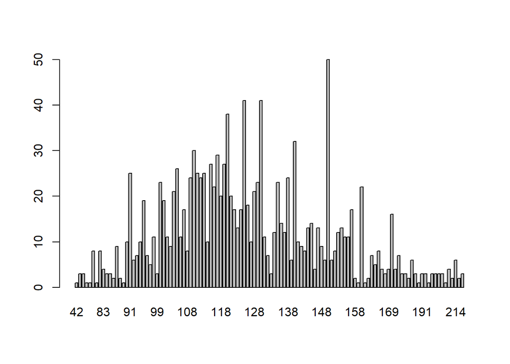

```r
barplot(table(data$Systolic.blood.pressure))
```

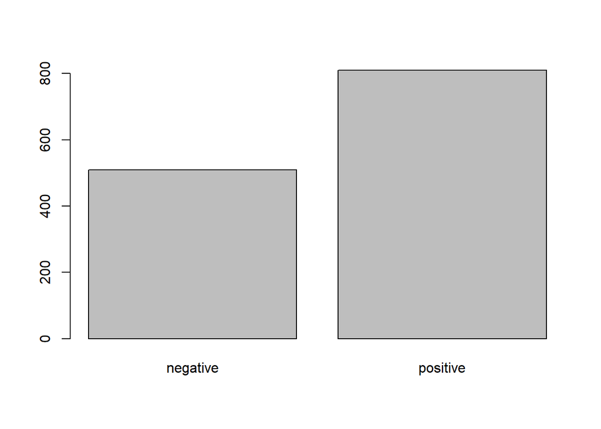

```r
##Ce diagramme en barres montre que le nombre de cas positifs est supérieur au nombre de cas négatifs dans la variable Result. Cela indique une prédominance des résultats positifs dans l’échantillon.
barplot(table(data$Result))
```

```r
##Le résumé statistique montre que l’âge des patients varie de 14 à 103 ans, avec une moyenne de 56,2 ans. La majorité des patients a entre 47 et 65 ans, ce qui correspond à l’intervalle interquartile.
summary(data)
```

```
##       Age             Gender         Heart.rate      Systolic.blood.pressure
##  Min.   : 14.00   Min.   :0.0000   Min.   :  20.00   Min.   : 42.0
##  1st Qu.: 47.00   1st Qu.:0.0000   1st Qu.:  64.00   1st Qu.:110.0
##  Median : 58.00   Median :1.0000   Median :  74.00   Median :124.0
##  Mean   : 56.19   Mean   :0.6596   Mean   :  78.34   Mean   :127.2
##  3rd Qu.: 65.00   3rd Qu.:1.0000   3rd Qu.:  85.00   3rd Qu.:143.0
##  Max.   :103.00   Max.   :1.0000   Max.   :1111.00   Max.   :223.0
##  Diastolic.blood.pressure  Blood.sugar        CK.MB            Troponin
##  Min.   : 38.00           Min.   : 35.0   Min.   :  0.321   Min.   : 0.0010
##  1st Qu.: 62.00           1st Qu.: 98.0   1st Qu.:  1.655   1st Qu.: 0.0060
##  Median : 72.00           Median :116.0   Median :  2.850   Median : 0.0140
##  Mean   : 72.27           Mean   :146.6   Mean   : 15.274   Mean   : 0.3609
##  3rd Qu.: 81.00           3rd Qu.:169.5   3rd Qu.:  5.805   3rd Qu.: 0.0855
##  Max.   :154.00           Max.   :541.0   Max.   :300.000   Max.   :10.3000
##       Result
##  negative:509
##  positive:810
##
##
##
##
```

```r
summary(data$Age)
```

```
##    Min. 1st Qu.  Median    Mean 3rd Qu.    Max.
##   14.00   47.00   58.00   56.19   65.00  103.00
```

```r
subset(data, data$Age < 50)
```

```
##      Age Gender Heart.rate Systolic.blood.pressure Diastolic.blood.pressure
## 2     21      1         94                      98                       46
## 7     32      0         40                     179                       68
## 9     44      0         60                     154                       81
## 11    44      0         60                     166                       90
## 15    47      1         76                     120                       70
## 18    45      0         70                     100                       68
## 19    37      0         72                     107                       86
## 20    45      1         60                     109                       65
## 22    48      1        135                      98                       60
## 24    30      1         63                     110                       68
## 27    42      1         65                     150                       68
## 29    47      0         66                     134                       57
## 32    35      1         62                     137                       61
## 40    34      1         96                     105                       75
```

[output cut: 753 more lines]

```r
##Genre 0 :Âge moyen : 57,96 ans Médiane : 60 ans Âge minimum : 14 ans, maximum : 103 ans Intervalle interquartile (IQR) : de 49 à 70 ans Genre 1 : Âge moyen : 55,28 ans Médiane : 56 ans Âge minimum : 19 ans, maximum : 100 ans IQR : de 47 à 65 ans
tapply(data$Age, data$Gender, summary)
```

```
## $`0`
##    Min. 1st Qu.  Median    Mean 3rd Qu.    Max.
##   14.00   49.00   60.00   57.96   70.00  103.00
##
## $`1`
##    Min. 1st Qu.  Median    Mean 3rd Qu.    Max.
##   19.00   47.00   56.00   55.28   65.00  100.00
```

[figure not shown]

```r
##Le code ci-dessous permet de représenter graphiquement la distribution de la variable **pression artérielle systolique** (`Systolic.blood.pressure`) présente dans le jeu de données `data`.  On utilise une couleur bleue pour les barres, un contour blanc, et on fixe la hauteur maximale de l’axe Y à 5 pour lisibilité.
hist(data$Systolic.blood.pressure, col = "blue", border = "white", ylim = c(0, 5), labels = TRUE, xlab = "Systolic blood pressure", ylab = "nb d'observations")
```

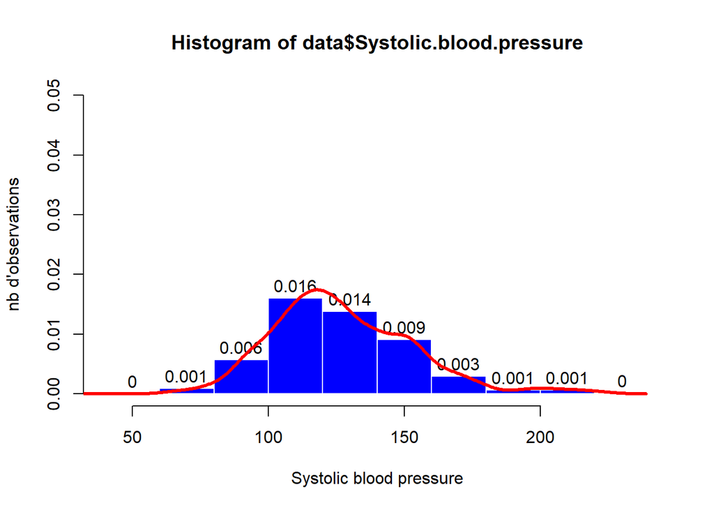

```r
## l'histogramme en bleu montre la distribution des valeurs, et la courbe rouge montre une estimation lissée de cette distribution (dite "courbe de densité").
hist(data$Systolic.blood.pressure, col = "blue", border = "white", ylim = c(0, 0.05), labels = TRUE, xlab = "Systolic blood pressure", ylab = "nb d'observations", prob = TRUE)
lines(density(data$Systolic.blood.pressure), lwd = 3, col = "red")
```

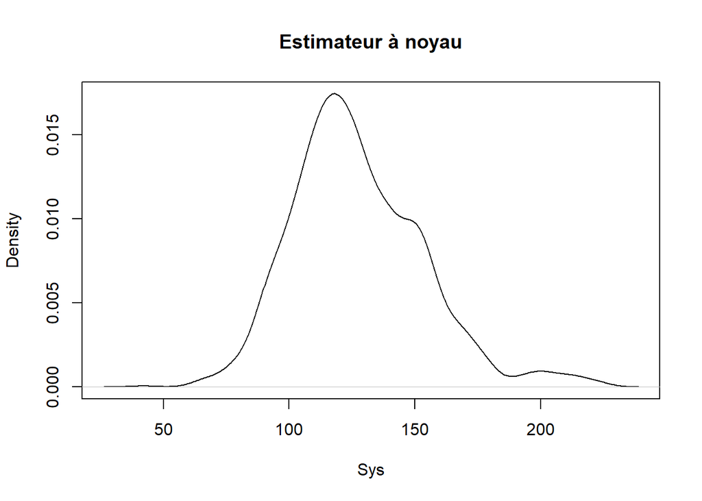

```r
plot(density(data$Systolic.blood.pressure), main = "Estimateur à noyau", xlab = "Sys")
```

```r
q <- levels(factor(data$Result))
q
```

```
## [1] "negative" "positive"
```

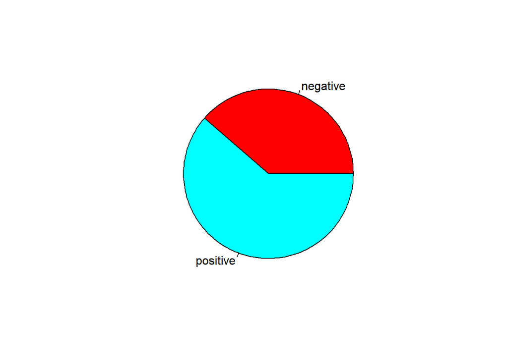

```r
pie(table(data$Result), col = rainbow(length(q)))
```

```r
r <- table(factor(data$Result))
prc <- (r / nrow(data)) * 100
prc
```

```
##
## negative positive
## 38.58984 61.41016
```

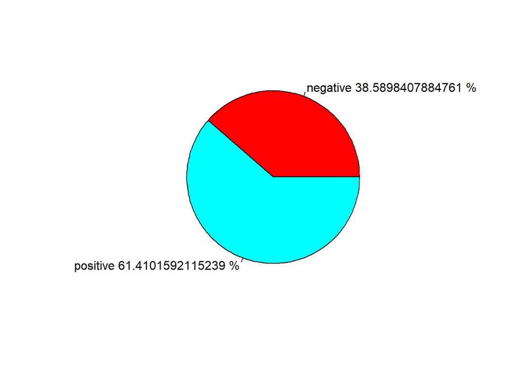

```r
pie(table(data$Result), col = rainbow(length(q)), labels = paste(q, prc, "%"))
```

```r
library(plotrix)
x <- table(data$Result)
d <- levels(factor(data$Result))
d
```

```
## [1] "negative" "positive"
```

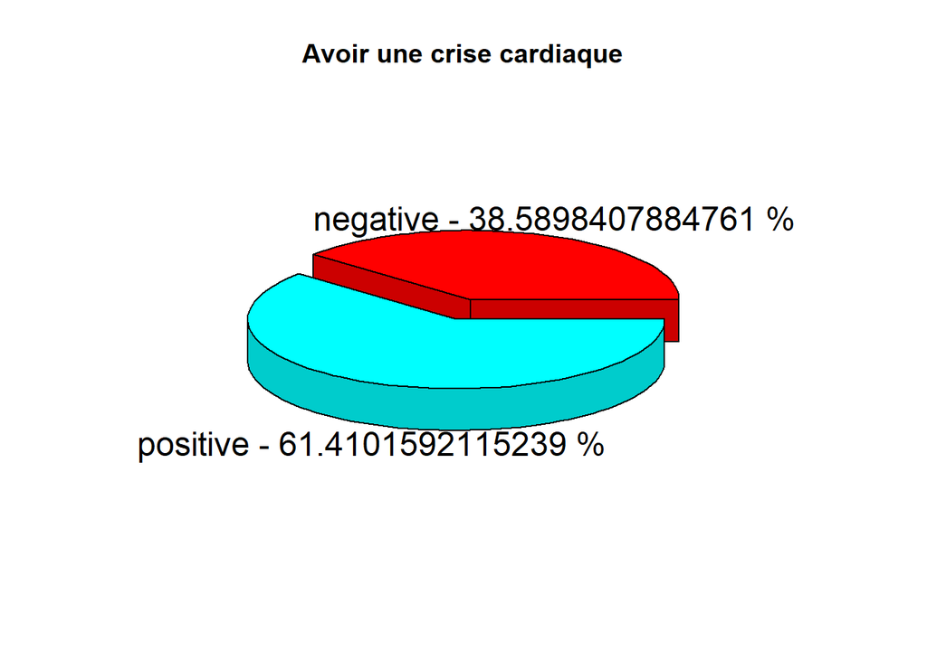

```r
pie3D(x, explode = 0.1, main = "Avoir une crise cardiaque", labels = paste(q, "-", prc, "%"))
```

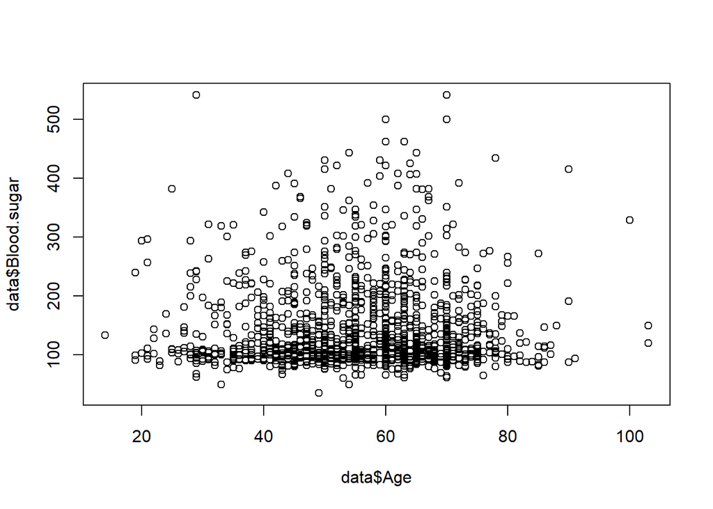

```r
plot(x = data$Age, y = data$Blood.sugar)
```

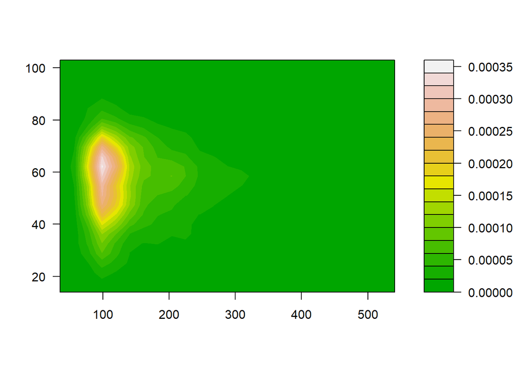

```r
library(MASS)
tmp <- data[, c("Blood.sugar", "Age")]
tmp <- tmp[complete.cases(tmp), ]
filled.contour(kde2d(tmp$Blood.sugar, tmp$Age), color = terrain.colors)
```

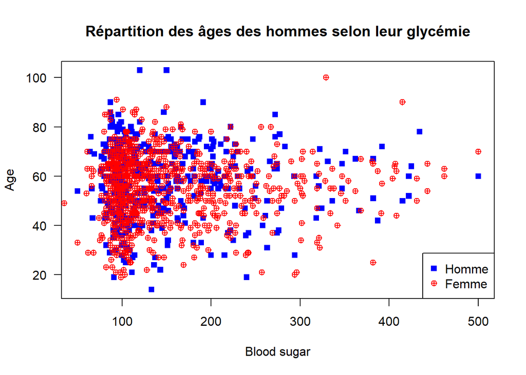

```r
plot(data$Blood.sugar[data$Gender == "0"], data$Age[data$Gender == "0"], pch = 15, col = "blue", main = "Répartition des âges des hommes selon leur glycémie", xlab = "Blood sugar", ylab = "Age", las = 1)
points(data$Blood.sugar[data$Gender == "1"], data$Age[data$Gender == "1"], pch = 10, col = "red")
legend(x = "bottomright", legend = c("Homme", "Femme"), col = c("blue", "red"), pch = c(15, 10))
```

```r
cor(data$Blood.sugar, data$Age, use = "complete.obs")
```

```
## [1] -0.004192985
```

```r
reg <- lm(data$Age ~ data$Blood.sugar)
summary(reg)
```

```
##
## Call:
## lm(formula = data$Age ~ data$Blood.sugar)
##
## Residuals:
##     Min      1Q  Median      3Q     Max
## -42.202  -9.166   1.768   8.858  46.811
##
## Coefficients:
##                    Estimate Std. Error t value Pr(>|t|)
## (Intercept)      56.3038050  0.8264310  68.129   <2e-16 ***
## data$Blood.sugar -0.0007638  0.0050192  -0.152    0.879
## ---
## Signif. codes:  0 '***' 0.001 '**' 0.01 '*' 0.05 '.' 0.1 ' ' 1
##
## Residual standard error: 13.65 on 1317 degrees of freedom
## Multiple R-squared:  1.758e-05,  Adjusted R-squared:  -0.0007417
## F-statistic: 0.02315 on 1 and 1317 DF,  p-value: 0.8791
```

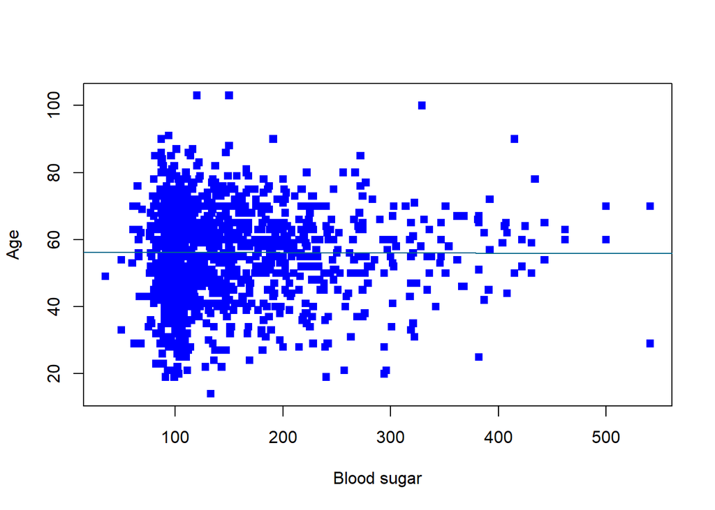

```r
plot(data$Blood.sugar, data$Age, ylab = "Age", xlab = "Blood sugar", col = "blue", pch = 15)
abline(reg, col = "deepskyblue4")
```

```r
t.test(data$Heart.rate)
```

```
##
##  One Sample t-test
##
## data:  data$Heart.rate
## t = 55.104, df = 1318, p-value < 2.2e-16
## alternative hypothesis: true mean is not equal to 0
## 95 percent confidence interval:
##  75.54774 81.12549
## sample estimates:
## mean of x
##  78.33662
```

```r
t <- table(data$Result, data$Gender)
t
```

```
##
##              0   1
##   negative 202 307
##   positive 247 563
```

```r
prop.table(t)
```

```
##
##                    0         1
##   negative 0.1531463 0.2327521
##   positive 0.1872631 0.4268385
```

```r
chisq.test(data$Result, data$Gender)
```

```
##
##  Pearson's Chi-squared test with Yates' continuity correction
##
## data:  data$Result and data$Gender
## X-squared = 11.356, df = 1, p-value = 0.0007519
```

```r
fisher.test(data$Result, data$Gender)
```

```
##
##  Fisher's Exact Test for Count Data
##
## data:  data$Result and data$Gender
## p-value = 0.0006678
## alternative hypothesis: true odds ratio is not equal to 1
## 95 percent confidence interval:
##  1.180500 1.903991
## sample estimates:
## odds ratio
##   1.499245
```

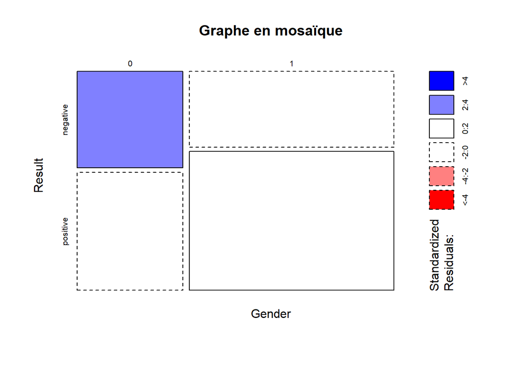

```r
mosaicplot(Gender ~ Result, data = data, shade = TRUE, main = "Graphe en mosaïque")
```

```r
library(FactoMineR)
library(factoextra)
```

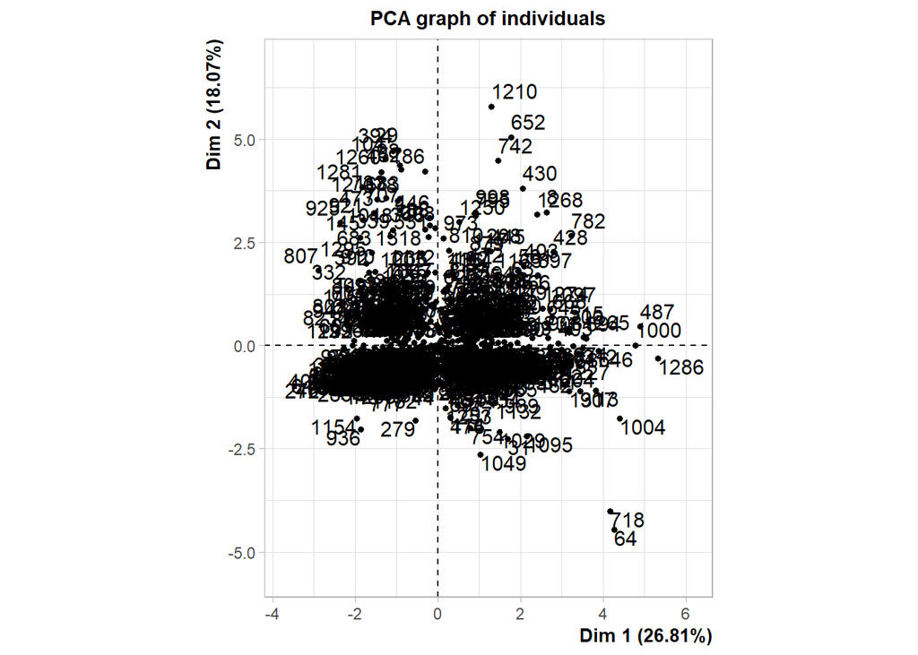

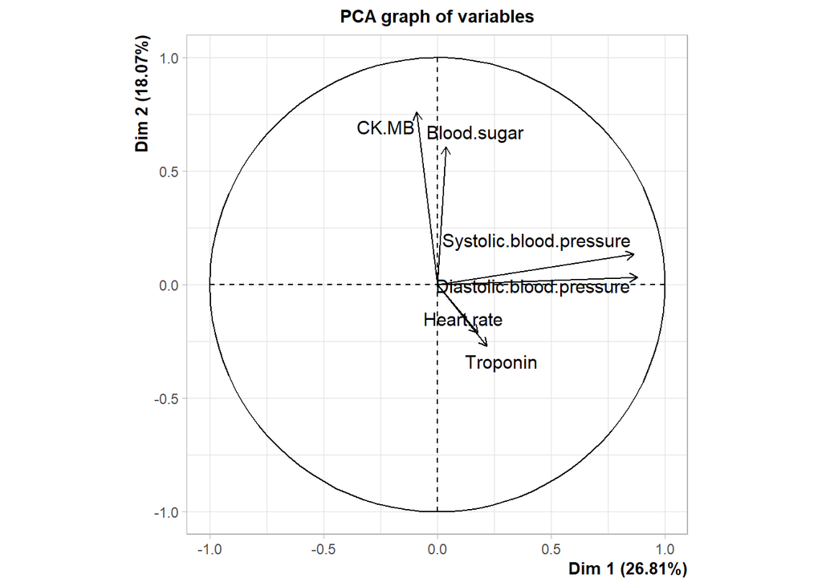

```r
library(corrplot)
resultat <- PCA(data[data$Result == "positive", c("Heart.rate", "Systolic.blood.pressure", "Diastolic.blood.pressure", "Blood.sugar", "CK.MB", "Troponin")], scale.unit = TRUE, graph = TRUE)
```

```r
eigval <- get_eigenvalue(resultat)
eigval
```

```
##       eigenvalue variance.percent cumulative.variance.percent
## Dim.1  1.6084011        26.806685                    26.80668
## Dim.2  1.0842992        18.071653                    44.87834
## Dim.3  1.0258413        17.097356                    61.97569
## Dim.4  0.9907185        16.511976                    78.48767
## Dim.5  0.8776842        14.628070                    93.11574
## Dim.6  0.4130557         6.884261                   100.00000
```

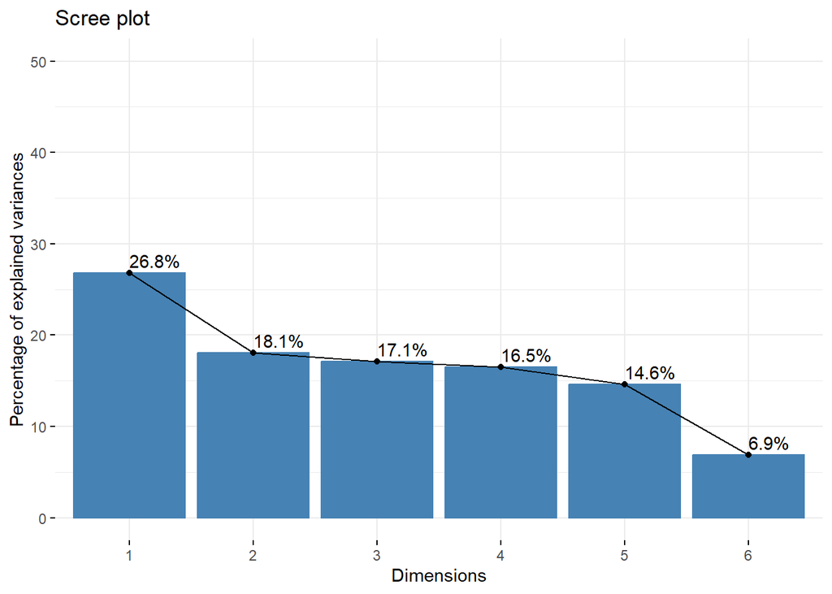

```r
fviz_eig(resultat, addlabels = TRUE, ylim = c(0, 50))
```

```r
var <- get_pca_var(resultat)
var
```

```
## Principal Component Analysis Results for variables
##  ===================================================
##   Name       Description
## 1 "$coord"   "Coordinates for the variables"
## 2 "$cor"     "Correlations between variables and dimensions"
## 3 "$cos2"    "Cos2 for the variables"
## 4 "$contrib" "contributions of the variables"
```

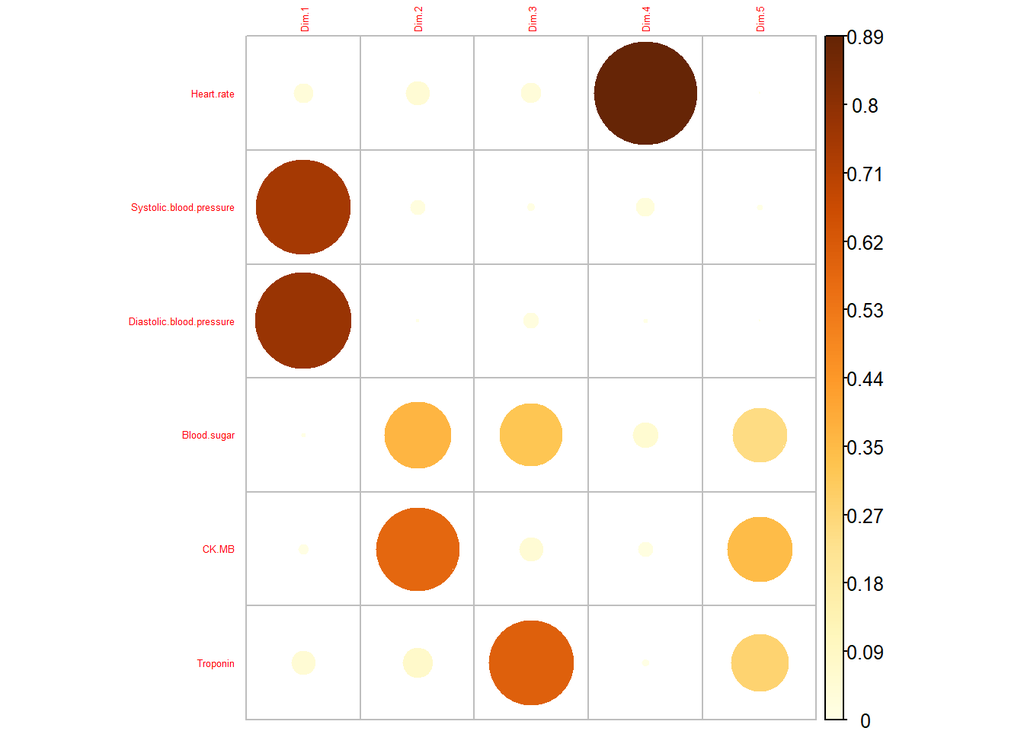

```r
corrplot(var$cos2, is.corr = FALSE, tl.cex = 0.4)
```

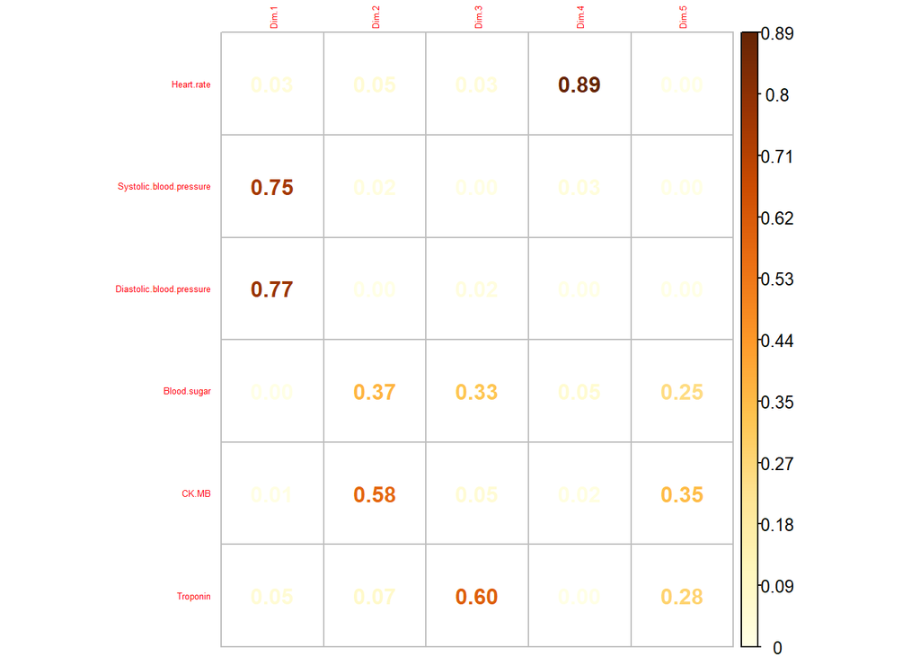

```r
corrplot(var$cos2, is.corr = FALSE, tl.cex = 0.4, method = "number")
```

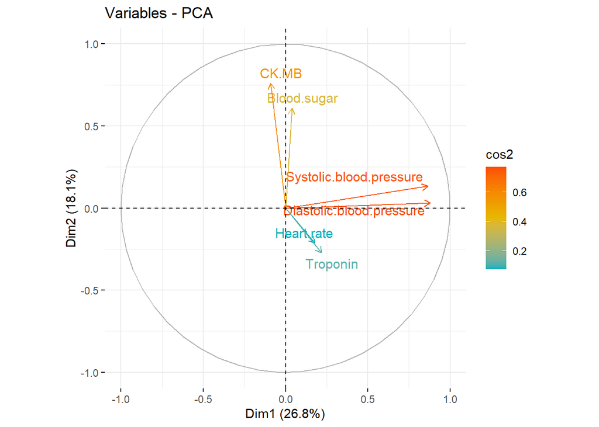

```r
fviz_pca_var(resultat,
             col.var = "cos2",
             gradient.cols = c("#00AFBB", "#E7B800", "#FC4E07"),
             repel = TRUE)
```

```r
data_matrix <- matrix(c(10, 20, 30, 40), nrow = 2)
chisq.test(data_matrix)
```

```
##
##  Pearson's Chi-squared test with Yates' continuity correction
##
## data:  data_matrix
## X-squared = 0.44643, df = 1, p-value = 0.504
```

```r
res <- CA(data_matrix, graph = TRUE)
valpropres <- get_eigenvalue(resultat)
valpropres
```

[output not shown]

```
##       eigenvalue variance.percent cumulative.variance.percent
## Dim.1  1.6084011        26.806685                    26.80668
## Dim.2  1.0842992        18.071653                    44.87834
## Dim.3  1.0258413        17.097356                    61.97569
## Dim.4  0.9907185        16.511976                    78.48767
## Dim.5  0.8776842        14.628070                    93.11574
## Dim.6  0.4130557         6.884261                   100.00000
```

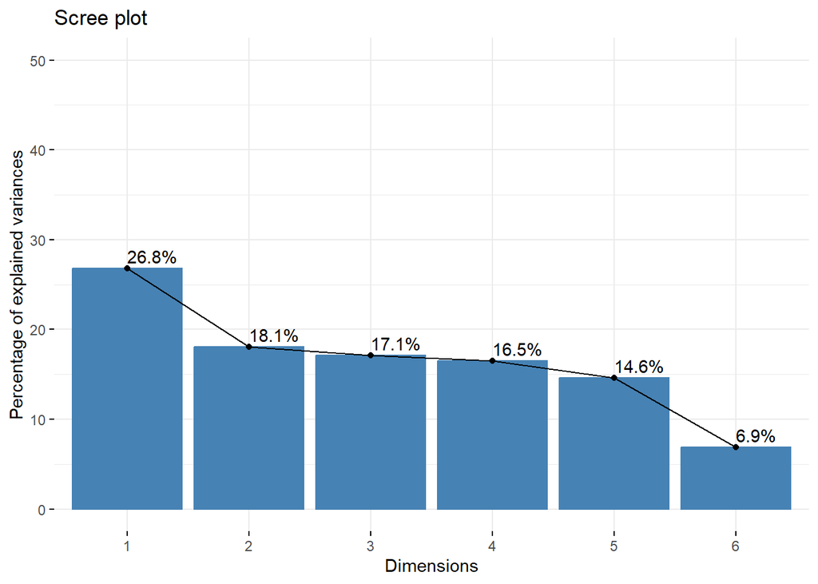

```r
fviz_screeplot(resultat, addlabels = TRUE, ylim = c(0, 50))
```

```r
ind <- get_pca_ind(resultat)
ind
```

```
## Principal Component Analysis Results for individuals
##  ===================================================
##   Name       Description
## 1 "$coord"   "Coordinates for the individuals"
## 2 "$cos2"    "Cos2 for the individuals"
## 3 "$contrib" "contributions of the individuals"
```